# The Price is Right!

Rotem Nizhar & Batel Mankovsky

## Notes on the differences between models 1, 2 & 3

In all submissions we used a Random Forest regressor after running randomized search CV, altought we tried to train several other models, as we also mentioned in our PDF summary (GB, KNN...).

#### Model 1:

We used most of the features that we devided were important, after much preprocessing and cleaning, but it was before we created additional features as well.  
The reason the model performed poorly was because we didn't notice that for the "heel_height" feature, all observations that didn't have the word low/medium/high in their "heel_height" data were left with the original value as their heel height, instead of receiving "other" as a value. That caused our model to have many many dummy features after the encoding of categorical data, which were also of course non informative and probably caused overfitting.

#### Model 2:

Here we of course fixed the previous problem, and not only gave all unknown observations the category "other" for heel height, we also extracted the heel height and the unit (inch/cm/mm) from the string, which worked for a lot of observations. Then, we converted all heights to centimeters, and then divided it to 6 categories of height. We hoped this feature will somehow improve the model, but we saw only a small improvement when we checked it.

Additionaly, we extracted several words from the title and the seller notes that seemed to us like a good indication of the priciness of the shoe (and we also backed it with data of the average price with and without these words). We created a binary feature that is 1 if one of those words exists in the title/notes, and 0 otherwise.

#### Model 3:

The biggest change we introduced to the features in our 3rd model is that we added additional features that represent the priciness of the brands.  
The first one is a numerical feature that for every brand (known brand from the train data only) with a mean log price above 4, puts it's mean log price as the value. For all other brands, and if the brand is unknown or empty, we put the mean log price of all the other brands (that are cheaper, and have a mean log price less than 4). The reason behind this feature was to give more importance to expensive brands, even if we have bery few observations of them in the train data.

Additionally, we created a feature that orders the brands by their average price, and ranks them accordingly. For unknown on never seen before brands, we give them the average rank. This is also a numerical feature that we created to strengthen the brand's importance, even if a brand appears very few times in the data.

These 2 features seemed to have a very good affect on the model, and along with a few other features we indroduced at this stage (listed below) gave us a RMSE of ~0.52.

The additional features were:

- Extracting "fancy" words from the color feature, after we saw a correlation between their appearance and the price.
- Creating a feature that counts the number of missing values for each observation, and creating 7 categories by number of missing values. The idea behind this feature was that during EDA we saw that observation we a lot of missing data tended to be more expansive.

#### Model 4

we tried something different and ran a NN, but probably had some configuration issue as the results on the train set were somewhat un-calibrated, and we didn't have the time to investigate.

## Imports & Settings

```python
import json
import re
import numpy as np
import pandas as pd
import seaborn as sns
import matplotlib.pyplot as plt

# Regressors
from sklearn.ensemble import RandomForestRegressor
from lightgbm import LGBMRegressor

# Regression Metrics
from sklearn.metrics import mean_squared_error

# Model selection
from sklearn.model_selection import train_test_split, GridSearchCV, cross_val_score, RepeatedKFold
from sklearn.model_selection import RandomizedSearchCV

%matplotlib inline
%run data_preparation_for_model.ipynb # <-- Our functions for processing and creating the final DFs for the model
```

### Prepare Data

```python
df_train = pd.read_csv('./data/ebay_women_shoes_train.csv')
df_train["log_price"] = np.log(df_train.price)

X_train, X_test, y_train, y_test =  prepare_train_test_data(df_train)
```

### Rndomized Search CV - Random Forest

```python
# Number of trees in random forest
n_estimators = [int(x) for x in np.linspace(start = 400, stop = 1600, num = 7)]

# Number of features to consider at every split
max_features = ['auto', 'sqrt']

# Maximum number of levels in tree
max_depth = [int(x) for x in np.linspace(10, 110, num = 6)]
max_depth.append(None)

# Minimum number of samples required to split a node
min_samples_split = [2, 5, 10]

# Minimum number of samples required at each leaf node
min_samples_leaf = [1, 2, 4]

# Method of selecting samples for training each tree
bootstrap = [True, False]

# Create the random grid
random_grid = {'n_estimators': n_estimators,
               'max_features': max_features,
               'max_depth': max_depth,
               'min_samples_split': min_samples_split,
               'min_samples_leaf': min_samples_leaf,
               'bootstrap': bootstrap}
```

```python
# Rndomized Search CV - search for best hyperparameters

# First create the base model to tune
rf = RandomForestRegressor()

# Random search of parameters, using 3 fold cross validation,
# search across 100 different combinations
rf_random = RandomizedSearchCV(
    estimator = rf,
    param_distributions = random_grid,
    n_iter = 100,
    cv = 3,
    verbose=2,
    random_state=42,
    n_jobs = -1,
    scoring='neg_root_mean_squared_error'
)

# Fit the random search model
rf_random.fit(X_train, y_train)  # <-- Might take a while

print(rf_random.best_params_)
```

```
Fitting 3 folds for each of 100 candidates, totalling 300 fits
{'n_estimators': 600, 'min_samples_split': 5, 'min_samples_leaf': 2, 'max_features': 'sqrt', 'max_depth': 70, 'bootstrap': False}
```

```python
# Evaluate model
y_pred = rf_random.best_estimator_.predict(X_train)
print("RMSE on training data:")
print(round(mean_squared_error(y_train, y_pred, squared=False), 4))

y_pred_test = rf_random.best_estimator_.predict(X_test)
print("RMSE on (our) test data:")
print(round(mean_squared_error(y_test, y_pred_test, squared=False), 4))
```

```
RMSE on training data:
0.3444
RMSE on (our) test data:
0.5137
```

```
Feature: f_brand_ranking                                    Importance: 0.2619050982147061
Feature: f_pricy_brands_mean_log_price                      Importance: 0.17694810018674276
Feature: f_is_luxury_brand                                  Importance: 0.06960086487025656
Feature: f_brand_2                                          Importance: 0.05106499043918853
Feature: f_country_region_of_manufacture_japan              Importance: 0.046123603536946
Feature: f_brand_chanel                                     Importance: 0.030613622592224117
Feature: f_brand_11                                         Importance: 0.020258344860469638
Feature: f_has_numbered_style                               Importance: 0.01906256717668859
Feature: f_brand_13                                         Importance: 0.015635499185482182
Feature: f_brand_10                                         Importance: 0.015337572825193952
Feature: f_na_vals                                          Importance: 0.014799043349535395
Feature: f_style_None                                       Importance: 0.014301157688860398
Feature: f_brand_chloe                                      Importance: 0.013799873585669954
Feature: f_returns_True                                     Importance: 0.01368253747692065
Feature: f_returns_False                                    Importance: 0.013177126004922041
Feature: f_brand_8                                          Importance: 0.012085418386255282
Feature: f_fast_safe_shipping_True                          Importance: 0.01042720172111177
Feature: f_country_region_of_manufacture_None               Importance: 0.01038466702557676
Feature: f_style_comfort                                    Importance: 0.009212918446247605
Feature: f_fast_safe_shipping_False                         Importance: 0.009059127167710726
Feature: f_category_comfort                                 Importance: 0.008316896653131874
Feature: f_brand_7                                          Importance: 0.007702362485992487
Feature: f_longtime_member_False                            Importance: 0.007543465866133313
Feature: f_brand_12                                         Importance: 0.007461876848922508
Feature: f_brand_3                                          Importance: 0.007398119803214938
Feature: f_category_heels                                   Importance: 0.006900439060621277
Feature: f_category_flats                                   Importance: 0.006312497757108328
Feature: f_brand_4                                          Importance: 0.0057398860508531355
Feature: f_material_upper_material_other                    Importance: 0.0056994070230380976
Feature: f_brand_1                                          Importance: 0.005678357040105858
Feature: f_longtime_member_True                             Importance: 0.005634368308957878
Feature: f_brand_14                                         Importance: 0.005207898760781848
Feature: f_style_Other                                      Importance: 0.004653496897241465
Feature: f_material_upper_material_leather                  Importance: 0.004590421704338355
Feature: f_brand_6                                          Importance: 0.00418628585941587
Feature: f_heel_height_Unknown                              Importance: 0.0036312006300279194
Feature: f_brand_5                                          Importance: 0.0033807771060286257
Feature: f_pricy_words                                      Importance: 0.0032470655953557204
Feature: f_same_day_shipping_False                          Importance: 0.003235325975561046
Feature: f_same_day_shipping_True                           Importance: 0.0032164105286729924
```

[output cut: 65 more lines]

```
Feature: f_material_upper_material_velvet                   Importance: 9.291365640333616e-05
Feature: f_country_region_of_manufacture_germany            Importance: 8.621017379770857e-05
Feature: f_occasion_wedding                                 Importance: 8.30405064652957e-05
Feature: f_country_region_of_manufacture_portugal           Importance: 7.277465386089623e-05
Feature: f_heel_type_Flat                                   Importance: 6.720248435549795e-05
Feature: f_material_upper_material_manmade                  Importance: 5.750285347426509e-05
Feature: f_country_region_of_manufacture_mexico             Importance: 5.2951310555118346e-05
Feature: f_occasion_flat                                    Importance: 3.200999504238923e-05
Feature: f_country_region_of_manufacture_australia          Importance: 2.6834212412504643e-05
Feature: f_country_region_of_manufacture_israel             Importance: 2.6266650377546525e-05
Feature: f_material_upper_material_linen                    Importance: 2.0283501297300002e-05
Feature: f_occasion_business                                Importance: 6.402093792422129e-06
Feature: f_country_region_of_manufacture_united kingdom     Importance: 4.8343357425044935e-06
Feature: f_material_upper_material_nylon                    Importance: 4.594811306291569e-06
Feature: f_occasion_outdoor                                 Importance: 1.0517890305757461e-06
```

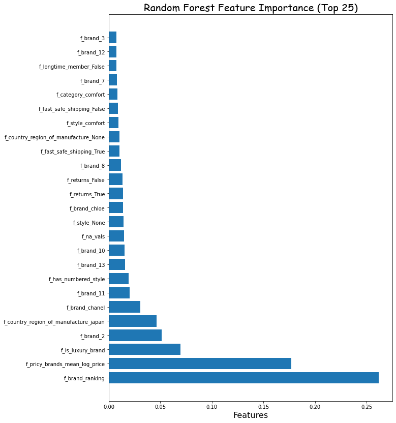

```python
# View the feature importances
feature_importances = list(zip(X_train, rf_random.best_estimator_.feature_importances_))
feature_importances_ranked = sorted(feature_importances, key = lambda x: x[1], reverse = True)

# Print out the feature and their importances
[print('Feature: {:50} Importance: {}'.format(*pair)) for pair in feature_importances_ranked];

# Plot the top 25 important features
feature_names_25 = [i[0] for i in feature_importances_ranked[:25]]
y_ticks = np.arange(0, len(feature_names_25))
x_axis = [i[1] for i in feature_importances_ranked[:25]]
plt.figure(figsize = (10, 14))
plt.barh(feature_names_25, x_axis)   #horizontal barplot
plt.title('Random Forest Feature Importance (Top 25)',
          fontdict= {'fontname':'Comic Sans MS','fontsize' : 20})
plt.xlabel('Features',fontdict= {'fontsize' : 16})
plt.show()
```